# Analisis de Datos Omicos. Segunda PEC

Alex Sanchez

Enero 2022

# 1 Introducción

## 1.1 Solución de la PEC-2

*El enunciado de la PEC establece unas directrices para la solución. por ejemplo que el código esté en un anexo para facilitar la legibilidad o que se incluya una sección de materiales y métodos.*

*La solución que os proporcionamos está pensada para ayudar a entender el proceso y los detalles de los análisis, lo que se podría o debería haber hecho, por lo que ésta estructura de OBJETIVOS -> METODOS -> RESULTADOS -> DISCUSION -> Apéndices, puede no ser tan obvia.*

*En todo caso, es una propuesta de solución que podéis utilizar para contrastar con la vuestra y, eventualmente, para entender mejor el porqué de cada paso.*

La solución se encuentra disponible, y actualizada (constantemente) en https://github.com/ASPteaching/ADO20221-PEC2-RNASeq.git

## 1.3 Objetivos

Este ejercicio tiene un doble objetivo - Implementar y ejecutar un pipeline básico de análisis de datos de RNA-seq, adaptándolo de otros pre-existentes. - Aplicar dicho pipe-line al análisis de unos datos públicos que se proporcionan con este fin. - Un tercer objetivo, que puede considerarse implícito en lo anterior es comunicar el proceso y los resultado siguiendo los estándares habituales de ciencia de datos (R/Rmarkdown).

## 1.4 Infraestructura informática para el análisis

Este estudio se llevará a cabo usando R/Bioconductor por lo que es preciso tener instaladas un conjunto de librerías. Esto puede hacerse siguiendo el procedimiento descrito a continuación.

**El código que se presenta debería ejecutarse tan sólo una vez!**

```r
if (!require(BiocManager)) {
    install.packages("BiocManager", dep = TRUE)
}

installifnot <- function(pckgName, BioC = TRUE) {
    if (BioC) {
        if (!require(pckgName, character.only = TRUE)) {
            BiocManager::install(pckgName)
        }
    } else {
        if (!require(pckgName, character.only = TRUE)) {
            install.packages(pckgName, dep = TRUE)
        }
    }
}
installifnot("limma")
installifnot("edgeR")
# installifnot('DESeq2')
installifnot("org.Hs.eg.db")
installifnot("clusterProfiler")
installifnot("dplyr", BioC = FALSE)
installifnot("gplots", BioC = FALSE)
installifnot("ggvenn", BioC = FALSE)
installifnot("pheatmap")
installifnot("stringi", BioC = FALSE)
installifnot("prettydoc", BioC = FALSE)
installifnot("ggnewscale", BioC = FALSE)
```

Puede resultar útil, aunque no es para nada imprescindible, disponer de, al menos dos, directorios específicos: - `datos` (o un nombre similar) donde guardar y de donde cargar los datos. - `results`o (o un nombre similar) donde escribir los resultados.

Estos directorios pueden crearse antes del inicio de la ejecución del pipeline o comprobar su existencia en cada ejecución, creándolos en caso de que estén ausentes.

# 2 Los datos para el análisis

## 2.1 Obtención de los datos y selección de las muestras

Los datos proporcionados no son los obtenidos directamente del proceso de secuenciación, imágenes o archivos FastQ, sino el resultado de pre-procesar éstos, es decir *un tabla de contajes*, almacenada en el archivo `Rawcounts.csv`, que contiene el número de “reads” para cada muestra en cada tránscrito (60683 filas y 34 columnas).

### 2.1.1 Lectura de la matriz de contajes

Los datos del archivo `Rawcounts.csv` deben leerse. Normalmente el proceso de lectura crea un objeto `data.frame`o un `tibble`, si se usa `tidyverse`, pero es práctico convertir dicho objeto en una *matriz* que es el formato utilizado por la mayoría de paquetes de análisis.

Con la información sobre los grupos u otras covariables o variables auxiliares se creará un objeto (el habitual “targets”) que debe estar *sincronizado* con el anterior.

Los nombres de fila del objeto “targets” deben coincidir-o al menos identificarse- con los nombres de columna de la matriz de contajes.

# 3 Preprocesado de los datos

## 3.1 Selección aleatoria de muestras

Para obtener una muestra aleatoria que tenga 10 individuos por grupo debemos sortear las columnas de cada tipo (“COVID” y “SANO”) por separado. Con esta muestra crearemos un subconjunto de la matriz de expresión que tendrá los mismos genes y tan sólo 20 columnas.

La selección aleatoria la basaremos en la columna `group` del objeto `targets`.

*Una posible forma de realizar este sorteo* consiste en crear una función que extraiga un cierto número de filas de un tipo de grupo.

Con esta función se extraen 10 muestras al azar, de entre las 17 de cada grupo.

Una vez realizada la extracción aleatoria se actualizaran tanto los contajes como el objeto “targets”, de forma que la sincronización entre filas y columnas continua siendo válida.

```
[1] 60683    20
```

```
[1] 20  3
```

```
[1] 0
```

## 3.2 Estandarización de los contajes

Además de filtrar, es bueno expresar los contajes en “CPMs” es decir “counts per million”, lo que no modificará los resultados del filtraje, pero estandarizará los valores, lo que es útil y necesario para los análisis posteriores.

Para la estandarización se utilizará la función `cpm()` del paquete `edgeR`.

```
                COV178 COV176 COV155 COV157 COV147 COV150
ENSG00000223972      1      0      2      2      0      0
ENSG00000227232      3     13     20      2      0     16
ENSG00000278267      0      3      3      2      1      0
ENSG00000243485      0      0      0      0      0      1
ENSG00000284332      0      0      0      0      0      0
```

```
                   COV178    COV176    COV155    COV157     COV147     COV150
ENSG00000223972 0.0575402 0.0000000 0.1163313 0.1173623 0.00000000 0.00000000
ENSG00000227232 0.1726206 0.9503052 1.1633130 0.1173623 0.00000000 0.84819243
ENSG00000278267 0.0000000 0.2193012 0.1744970 0.1173623 0.07170342 0.00000000
ENSG00000243485 0.0000000 0.0000000 0.0000000 0.0000000 0.00000000 0.05301203
ENSG00000284332 0.0000000 0.0000000 0.0000000 0.0000000 0.00000000 0.00000000
```

Una vez los datos estan como CPMs, se procede a filtrarlos,

## 3.3 Filtraje de genes poco expresados

Los genes con recuentos muy bajos en todas las librerías proporcionan poca evidencia de expresión diferencial por lo que es habitual eliminar aquellos genes que, o bien son poco variables, o bien presentan poca o nula expresión en la mayoría de las muestras.

En este caso, siguiendo las indicaciones proporcionadas, se opta por *conservar únicamente aquellos genes que presentan algún valor en, al menos, tres muestras **de cada grupo***.

```
[1] 60683    20
```

```
[1] 29905    20
```

Aunque no sea más que un ejemplo basta con ver los dos primeros genes para comprobar como el primero no cumple la condición, en el grupo “SANO”, mientras que los siguientes sí que la cumplen. Por lo tanto, al filtrar desaparece el primer gen de la matriz filtrada, pero no los dos siguientes.

```
                   COV178    COV176    COV155    COV157     COV147     COV150
ENSG00000223972 0.0575402 0.0000000 0.1163313 0.1173623 0.00000000 0.00000000
ENSG00000227232 0.1726206 0.9503052 1.1633130 0.1173623 0.00000000 0.84819243
ENSG00000278267 0.0000000 0.2193012 0.1744970 0.1173623 0.07170342 0.00000000
                   COV177   COV153    COV179    COV180    HEA062    HEA061
ENSG00000223972 0.0000000 0.000000 0.0000000 0.0000000 0.0000000 0.0000000
ENSG00000227232 1.9885554 1.388085 0.1462825 0.6558384 0.0000000 0.3528731
ENSG00000278267 0.4349965 0.000000 0.2194237 0.0000000 0.2880235 0.2352487
                   HEA186    HEA071     HEA068    HEA067    HEA181     HEA069
ENSG00000223972 0.0000000 0.0000000 0.00000000 0.0000000 0.0000000 0.00000000
ENSG00000227232 0.4151761 0.1122282 0.06713275 0.0000000 0.2003508 0.06693886
ENSG00000278267 0.1779326 0.3366846 0.13426549 0.4268581 0.2003508 0.46857204
                   HEA063     HEA183
ENSG00000223972 0.0000000 0.00000000
ENSG00000227232 0.0000000 0.05465108
ENSG00000278267 0.1926772 0.32790646
 [ reached getOption("max.print") -- omitted 3 rows ]
```

```
                   COV178    COV176   COV155     COV157     COV147     COV150
ENSG00000227232 0.1726206 0.9503052 1.163313 0.11736232 0.00000000 0.84819243
ENSG00000278267 0.0000000 0.2193012 0.174497 0.11736232 0.07170342 0.00000000
ENSG00000233750 0.0000000 0.1462008 0.000000 0.05868116 0.07170342 0.05301203
                   COV177    COV153     COV179    COV180    HEA062    HEA061
ENSG00000227232 1.9885554 1.3880853 0.14628246 0.6558384 0.0000000 0.3528731
ENSG00000278267 0.4349965 0.0000000 0.21942369 0.0000000 0.2880235 0.2352487
ENSG00000233750 0.0000000 0.0000000 0.07314123 0.0000000 0.0000000 0.0000000
                    HEA186    HEA071     HEA068     HEA067     HEA181
ENSG00000227232 0.41517606 0.1122282 0.06713275 0.00000000 0.20035083
ENSG00000278267 0.17793260 0.3366846 0.13426549 0.42685808 0.20035083
ENSG00000233750 0.05931087 0.0561141 0.00000000 0.12195945 0.00000000
                    HEA069    HEA063     HEA183
ENSG00000227232 0.06693886 0.0000000 0.05465108
ENSG00000278267 0.46857204 0.1926772 0.32790646
ENSG00000233750 0.06693886 0.0000000 0.05465108
 [ reached getOption("max.print") -- omitted 3 rows ]
```

## 3.4 Uso de clases específicas para manejar los datos

Cuando se trabaja con distintos objetos referidos a unos mismos datos, como la matriz de contajes y el objeto “targets”, es útil disponer de clases contenedoras que permitan trabajar con todos ellos a la vez, lo que no sólo facilita el trabajo sino que ayuda a evitar “desincronizaciones”.

Éste es el caso de la clase `ExpressionSet` habitualmente utilizada con microarrays o de la clase que la generaliza, llamada `SummarizedExperiment`.

Para datos de contaje es habitual usar una clase similar a `ExpressionSet` llamada `DGEList`” pensadas para manejar datos de contajes , definida en el paquete `edgeR`. Esta clase, más simple que las anteriores, utiliza listas para almacenar recuentos de “reads” e información asociada de tecnologías de secuenciación o expresión génica digital. Puede encontrarse información al respecto en la ayuda del paquete `edgeR`.

```
An object of class "DGEList"
$counts
                   COV178    COV176   COV155     COV157     COV147     COV150
ENSG00000227232 0.1726206 0.9503052 1.163313 0.11736232 0.00000000 0.84819243
ENSG00000278267 0.0000000 0.2193012 0.174497 0.11736232 0.07170342 0.00000000
ENSG00000233750 0.0000000 0.1462008 0.000000 0.05868116 0.07170342 0.05301203
                   COV177    COV153     COV179    COV180    HEA062    HEA061
ENSG00000227232 1.9885554 1.3880853 0.14628246 0.6558384 0.0000000 0.3528731
ENSG00000278267 0.4349965 0.0000000 0.21942369 0.0000000 0.2880235 0.2352487
ENSG00000233750 0.0000000 0.0000000 0.07314123 0.0000000 0.0000000 0.0000000
                    HEA186    HEA071     HEA068    HEA067    HEA181     HEA069
ENSG00000227232 0.41517606 0.1122282 0.06713275 0.0000000 0.2003508 0.06693886
ENSG00000278267 0.17793260 0.3366846 0.13426549 0.4268581 0.2003508 0.46857204
ENSG00000233750 0.05931087 0.0561141 0.00000000 0.1219595 0.0000000 0.06693886
                   HEA063     HEA183
ENSG00000227232 0.0000000 0.05465108
ENSG00000278267 0.1926772 0.32790646
ENSG00000233750 0.0000000 0.05465108
 [ reached getOption("max.print") -- omitted 2 rows ]
29900 more rows ...

$samples
       group lib.size norm.factors sample group.1 cols
COV178 COVID 999119.5            1 COV178   COVID  red
COV176 COVID 999409.6            1 COV176   COVID  red
COV155 COVID 998791.1            1 COV155   COVID  red
COV157 COVID 999280.6            1 COV157   COVID  red
COV147 COVID 999173.2            1 COV147   COVID  red
15 more rows ...

$genes
                          genes
ENSG00000227232 ENSG00000227232
ENSG00000278267 ENSG00000278267
ENSG00000233750 ENSG00000233750
ENSG00000268903 ENSG00000268903
ENSG00000269981 ENSG00000269981
29900 more rows ...
```

Uno de los aspectos interesantes de estas clases es la posibilidad de extraer partes de todos los objetos a la vez con el operador de “subsetting”.

```
[1] 29905    20
```

```
       group lib.size norm.factors sample group.1 cols
COV178 COVID 999119.5            1 COV178   COVID  red
COV176 COVID 999409.6            1 COV176   COVID  red
COV155 COVID 998791.1            1 COV155   COVID  red
COV157 COVID 999280.6            1 COV157   COVID  red
COV147 COVID 999173.2            1 COV147   COVID  red
HEA062  SANO 999873.0            1 HEA062    SANO blue
HEA061  SANO 999493.0            1 HEA061    SANO blue
HEA186  SANO 999378.6            1 HEA186    SANO blue
HEA071  SANO 999908.4            1 HEA071    SANO blue
HEA068  SANO 999388.5            1 HEA068    SANO blue
```

```
 [1] "COV178" "COV176" "COV155" "COV157" "COV147" "HEA062" "HEA061" "HEA186"
 [9] "HEA071" "HEA068"
```

Aunque podríamos haber creado el objeto a partir de todas las muestras, y haber realizado la extracción de genes y muestras posteriormente, hemos optado por no hacerlo para facilitar el seguimiento del proceso.

## 3.5 Normalización

Además d estandarizar los contajes, es importante eliminar otros los sesgos de composición entre librerías. Esto puede hacerse aplicando la normalización por el método TMM que genera un conjunto de factores de normalización, donde el producto de estos factores y los tamaños de librería definen el tamaño efectivo de la biblioteca.

La función `calcNormFactors`, de la librería `edgeR`, calcula los factores de normalización entre librerías.

Esto no modificará la matriz de contajes, pero actualizará los factores de normalización en el objeto DGEList (sus valores predeterminados son 1).

```
                   COV178    COV176   COV155     COV157     COV147
ENSG00000227232 0.1726206 0.9503052 1.163313 0.11736232 0.00000000
ENSG00000278267 0.0000000 0.2193012 0.174497 0.11736232 0.07170342
ENSG00000233750 0.0000000 0.1462008 0.000000 0.05868116 0.07170342
```

```
                   COV178    COV176   COV155     COV157     COV147
ENSG00000227232 0.1726206 0.9503052 1.163313 0.11736232 0.00000000
ENSG00000278267 0.0000000 0.2193012 0.174497 0.11736232 0.07170342
ENSG00000233750 0.0000000 0.1462008 0.000000 0.05868116 0.07170342
```

```
 [1] 1 1 1 1 1 1 1 1 1 1 1 1 1 1 1 1 1 1 1 1
```

```
 [1] 1.0727497 0.9600981 0.7901178 1.0201663 1.0604976 0.9250904 0.9694508
 [8] 0.9928292 0.9872257 1.0320142 1.0150899 0.9804980 0.9928723 0.9522990
[15] 1.0752809 1.0896598 0.9518347 1.1201619 1.0489551 1.0153059
```

Es decir, *aunque no se observen cambios en la matriz de contajes*, cuando se utilizan estos factores de normalización en algún cálculo la importancia de las distintas columnas se tendrá en cuenta.

**Resumiendo**

Los análisis que se realicen a continuación se basaran en la matriz de contajes, filtrada, estandarizada y normalizada, sobre la que además se toman logaritmo base dos.

Esta será nuestra matriz de partida para los análisis siguientes,

# 4 Exploración de los datos

Una vez descartados los genes poco expresados y con los recuentos almacenados en un objeto `DGEList`, podemos`proceder a realizar algunos gráficos exploratorios para determinar si los datos aparentan buena calidad y/o si presentan algun problema.

## 4.1 Distribución de los contajes

Un diagrama de cajas con los datos, normalizados o no, muestra que la distribución de los contajes es muy asimétrica, lo que justifica la decisión de trabajar con los logaritmos de los datos.

La transformación logarítmica puede hacerse directamente pero es mejor usar la función `cpm`, como se ha hecho, que agrega una pequeña cantidad para evitar tomar logaritmos de cero.

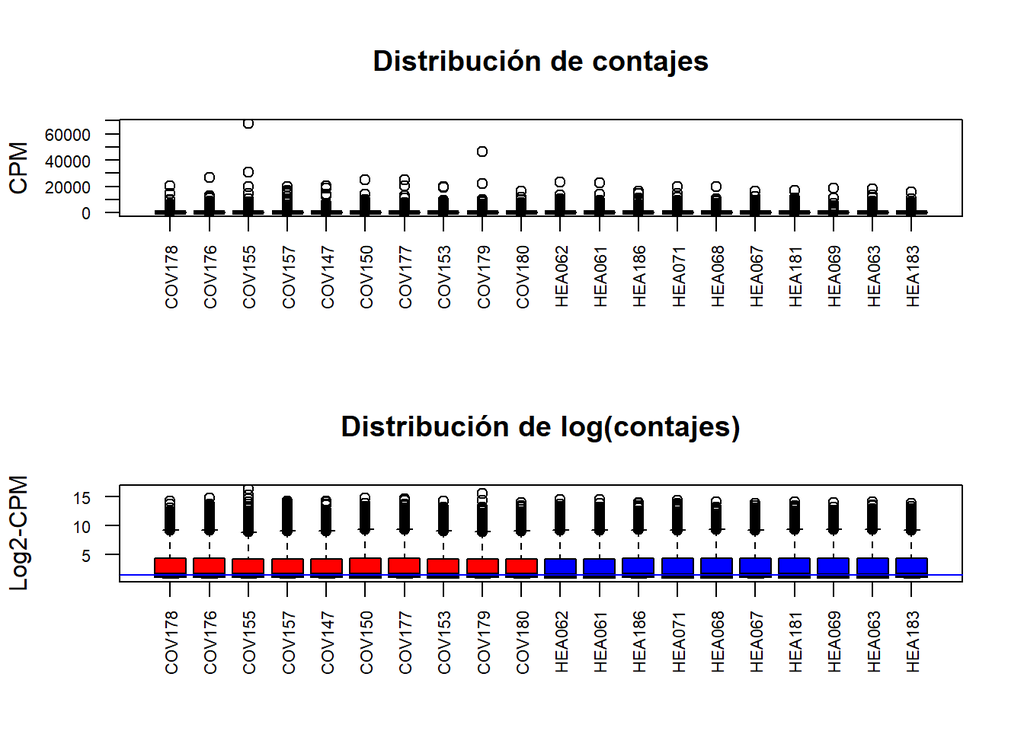

## 4.2 Análisis de similaridad entre las muestras

En general, en un estudio experimental en donde buscamos comparar distintas condiciones o tratamientos, esperaremos que las muestras pertencientes al mismo grupo *se parezcan* más entre ellas que a las de los otros grupos.

Esta idea intuitiva puede concretarse a través de calcular y visualizar de alguna forma la similaridad entre las muestras.

Esto puede hacerse de distintas formas, pero algunas de las más habituales son, el *cluster* o agrupamiento jerárquico y los métodos de reducción de la dimensión como el análisis de componentes principales (PCA) o el escalamiento multidimensional (MDS). Éste último tiene la ventaja que permite visualizar en dimensión reducida las similaridades entre muestras, más que los datos directos que es lo que hace el PCA.

### 4.2.1 Distancia entre muestras

La función `dist` permite calcular una *matriz de distancias* que contiene las comparaciones dos a dos entre todas las muestras. Por defecto se utiliza una distancia euclídea.

```
       COV178 COV176 COV155 COV157 COV147 COV150 COV177 COV153 COV179 COV180
COV176   65.9
COV155   95.5   70.7
COV157   60.2   71.3   95.8
       HEA062 HEA061 HEA186 HEA071 HEA068 HEA067 HEA181 HEA069 HEA063
COV176
COV155
COV157
 [ reached getOption("max.print") -- omitted 16 rows ]
```

Las matrices de distancias se pueden visualizar directamente con un heatmap.

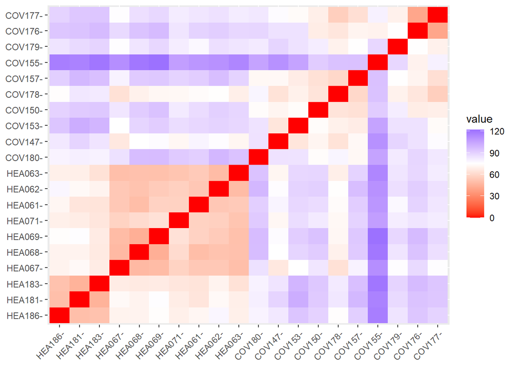

Como puede verse _las muestras tienden a agruparse por el factor SANO/COVID, aunque una de las muestras. COV155 se separa del resto de las del grupo COVID.

### 4.2.2 Agrupamiento jerárquico

Un agrupamiento jerárquico proporciona una representación alternativa, también basada en la matriz de distancias.

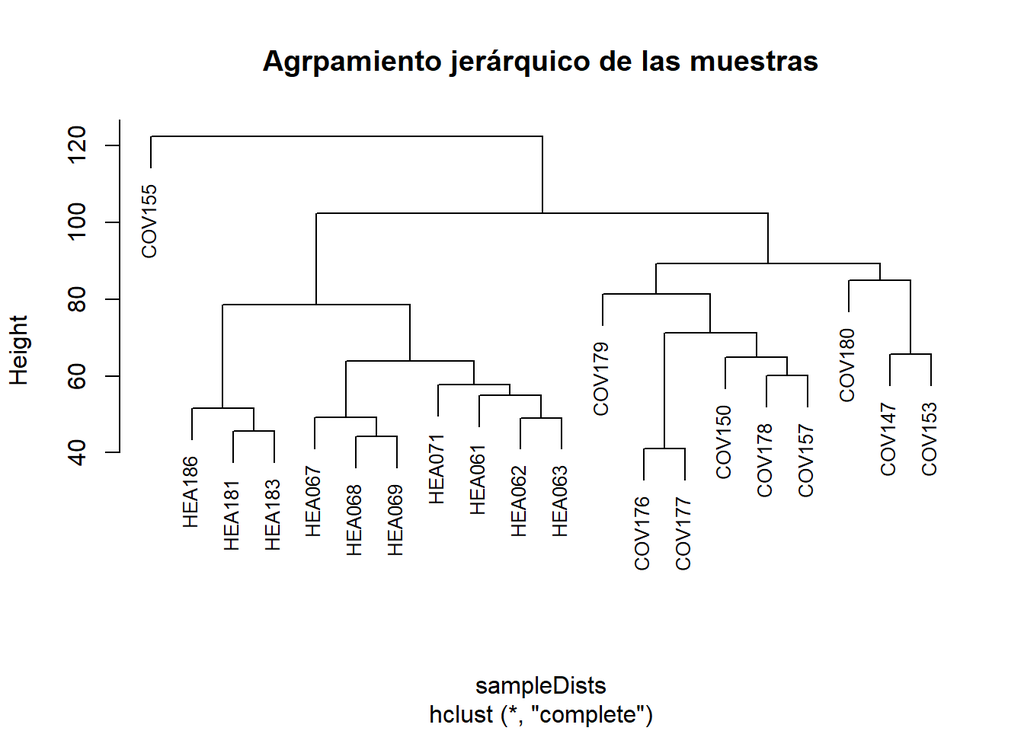

El dendrograma muestra la misma agrupación, sanos por un lado y COVID por otro, y el mismo comportamiento diferenciado de esta muestra COV155.

Una forma adicional de comprobar que, efectivamente, la mustra “COV155” difiere de las demas es verificar que el factor de normalización de dicha muestra es distinto al de los demás, lo que es coherente con el resto de visualizaciones y sugiere que es preciso *un mayor esfuerzo* para hacerla similar al resto.

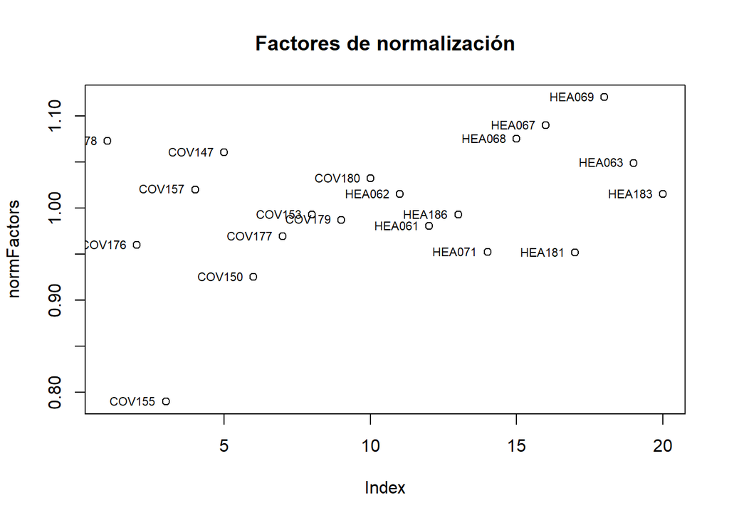

### 4.2.3 Visualización en dimensión reducida

Un enfoque complementario para determinar las principales fuentes de variabilidad en los datos es la visualización en dimensión reducida, ya sea de los datos o de la matriz de similaridades.

Para la primera representación es habitual basarse en el resultado de un análisis de componentes principales (PCA) que representan las direcciones a lo largo de las cuales la variación en la matriz de datos es máxima, con la ventaja de que dichas direcciones son ortogonales (es decir independientes) y que explica cada una más información que la siguiente, por lo que con unas pocas dimensiones se suele poder explicar un alto porcentaje de la variabilidad.

De forma análoga, el escalamiento multidimensional permite llevar a cabo una transformación similar a la del PCA, pero con la matriz de distancias, lo que proporciona una representación en dimensión reducida que describe con relativa fidelidad las diferencias y similaridades entre muestras.

Para esta segunda representación utilizaremos la función `plotMDS`. Es un poco difícil ver exactamente qué está pasando con la gráfica predeterminada, aunque vemos muestras que se agrupan en pares. Para hacer esta gráfica más informativa, podemos colorear las muestras de acuerdo con la información de agrupación (por ejemplo. Estado):

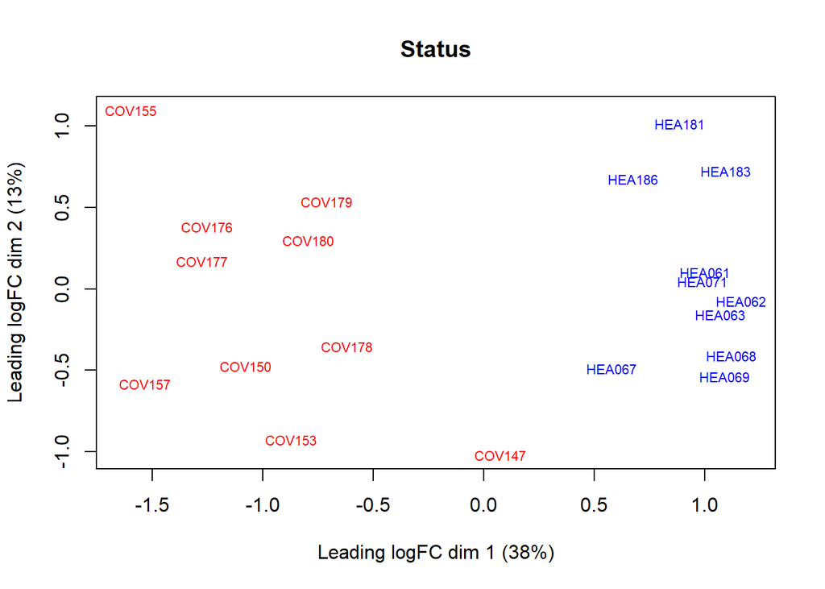

Como puede verse, el gráfico muestra la misma agrupación “natural” que las visualizaciones anterioreslo que sugiere que los grupos que se comparan parecen estar bien definidos.

## 4.3 Detección de efecto batch

La detección de efecto batch puede hacerse, bien mediante la visualización de las muestras o mediante análisis de las covariables. Puesto que no se disponen de covariables sólo resta observar las visualizaciones para determinar si éstas sugieren alguna agrupación “no natural”, es decir no ligada a la variable “estado de salud”.

Puesto que éste no es el caso, es decir, los datos se agrupan por SANOS/COVID, concluímos que *no parece* existir ninguna fuente de variación superpuesta, que pudiera atribuirse a un posible efecto batch.

# 5 Análisis de expresión diferencial

El objetivo del análisis de expresión diferencial es seleccionar genes cuya expresión difiere entre grupos.

Al tratarse de contajes, que no son variables contínuas, la comparación puede llevarse a cabo usando modelos lineales generalizados o extensiones de éstos, creadas específicamente para datos de secuenciación.

Este es el caso específicamente de `edgeR` o `DESEQ2`.

Una alternativa a estos paquetes es usar el paquete `limma`, que ofrece la función `voom`, que transforma los recuentos de “reads” en `logCMM`, teniendo en cuenta la relación media-varianza en los datos (Charity W. Law et al. 2014) y permite analizarlos mediante la aproximación habitual basada en modelos lineales.

## 5.1 Selección de genes usando limma-Voom

La ventaja principal de esta aproximación es que permite trabajar con toda la flexibilidad de los modelos lineales para representar diseños experimentales, y, en muchos casos , aprovechar la experiencia previa del usuario en el manejo de limma.

### 5.1.1 Matriz de diseño y de contrastes

Utilizando la variable `group` podemos definir una *matriz de diseño* y, sobre ésta, los *contrastes* que nos interesan.

```
       COVID SANO
COV178     1    0
COV176     1    0
COV155     1    0
COV157     1    0
COV147     1    0
COV150     1    0
COV177     1    0
COV153     1    0
COV179     1    0
COV180     1    0
HEA062     0    1
HEA061     0    1
HEA186     0    1
HEA071     0    1
HEA068     0    1
HEA067     0    1
HEA181     0    1
HEA069     0    1
HEA063     0    1
HEA183     0    1
attr(,"assign")
[1] 1 1
attr(,"contrasts")
attr(,"contrasts")$group
[1] "contr.treatment"
```

Dado que estamos interesados en las diferencias entre los grupos, necesitamos especificar qué comparaciones queremos llevar a cabo. Las comparaciones de interés se puede especificar utilizando la función `makeContrasts`. La matriz de contraste indica qué columnas de la matriz `design` vamos a comparar. En este caso tan sólo se llevará a cabo una comparación.

```
       Contrasts
Levels  CONTROLvsCOVID
  COVID              1
  SANO              -1
```

### 5.1.2 Transformación de los contajes

Tal como se ha indicado, no es posible aplicar un modelo lineal normal con datos de contajes. la transformación `voom` creará un nuevo objeto con campos equivalentes a los del DGELIST, en la que los contajes se han transdormado de forma que puedan ser analizados usando modelos lineales. O, mejor dicho, de forma que las inferencias realizadas, usando un modelo lineal normal resulten válidas.

```
An object of class "EList"
$genes
                          genes
ENSG00000227232 ENSG00000227232
ENSG00000278267 ENSG00000278267
ENSG00000233750 ENSG00000233750
ENSG00000268903 ENSG00000268903
ENSG00000269981 ENSG00000269981
29900 more rows ...

$targets
       group  lib.size norm.factors sample group.1 cols
COV178 COVID 1071805.1    1.0727497 COV178   COVID  red
COV176 COVID  959531.3    0.9600981 COV176   COVID  red
COV155 COVID  789162.6    0.7901178 COV155   COVID  red
COV157 COVID 1019432.4    1.0201663 COV157   COVID  red
COV147 COVID 1059620.8    1.0604976 COV147   COVID  red
15 more rows ...

$E
                    COV178     COV176     COV155      COV157     COV147
ENSG00000227232 -0.6721791  0.5959532  1.0756634 -0.72357822 -1.0835494
ENSG00000278267 -1.1000439 -0.4157354 -0.2265125 -0.72357822 -0.8902106
ENSG00000233750 -1.1000439 -0.5703489 -0.6583963 -0.86767048 -0.8902106
                      COV150      COV177     COV153     COV179     COV180
ENSG00000227232  0.543678517  1.36058616  0.9276420 -0.6095642  0.1646196
ENSG00000278267 -0.887347910 -0.05168947 -0.9892819 -0.4548874 -1.0443202
ENSG00000233750 -0.741965149 -0.95472232 -0.9892819 -0.7828384 -1.0443202
                      HEA062      HEA061     HEA186     HEA071     HEA068
ENSG00000227232 -1.021425688 -0.20045351 -0.1166635 -0.6372146 -0.9220740
ENSG00000278267 -0.365115111 -0.41455220 -0.5495710 -0.1866002 -0.7606736
ENSG00000233750 -1.021425688 -0.97085646 -0.8270624 -0.7759032 -1.1038324
                    HEA067      HEA181     HEA069     HEA063     HEA183
ENSG00000227232 -1.1236197 -0.44183370 -0.9822428 -1.0688228 -0.8717722
ENSG00000278267 -0.2331993 -0.44183370 -0.2095766 -0.5985676 -0.2938849
ENSG00000233750 -0.8087272 -0.92798340 -0.9822428 -1.0688228 -0.8717722
 [ reached getOption("max.print") -- omitted 2 rows ]
29900 more rows ...

$weights
```

[output cut: 8 more lines]

```
         [,15]     [,16]     [,17]     [,18]     [,19]     [,20]
[1,] 13.784345 13.238883 20.618515 12.218924 14.863925 16.538703
[2,]  7.879591  7.733364 10.153791  7.448762  8.146879  8.738441
[3,] 21.773920 20.702954 30.013211 18.796457 23.844140 27.055356
 [ reached getOption("max.print") -- omitted 2 rows ]
29900 more rows ...

$design
       COVID SANO
COV178     1    0
COV176     1    0
COV155     1    0
COV157     1    0
COV147     1    0
15 more rows ...
```

### 5.1.3 Selección de genes diferencialmente expresados

Como en el caso de los microarrays el objeto `voomObj` y las matrices de diseño y contrastes se utilizaran para ajustar un modelo y, a continuación realizar las comparaciones especificadas sobre el modelo ajustado. El proceso finaliza con la regularización del estimador del error usando la función `eBayes`.

### 5.1.4 Top tables

Los resultados de un análisis de expresión diferencial se pueden extraer con la función `topTable`. Esta función genera una tabla de resultados cuyas columnas contienen información acerca de los genes y la diferencia entre los grupos comparados. Concretamente:

```
                          genes    logFC  AveExpr        t      P.Value
ENSG00000211896 ENSG00000211896 5.504842 9.716587 13.08361 2.698829e-12
ENSG00000184661 ENSG00000184661 2.895926 1.686981 12.60920 5.803450e-12
ENSG00000117399 ENSG00000117399 3.613949 3.030221 12.33319 9.151878e-12
ENSG00000123485 ENSG00000123485 2.881957 2.012345 12.32809 9.229965e-12
ENSG00000166851 ENSG00000166851 3.502013 2.760586 11.96605 1.697491e-11
ENSG00000211962 ENSG00000211962 3.531360 5.155350 11.92748 1.812779e-11
                   adj.P.Val        B
ENSG00000211896 6.029599e-08 18.25429
ENSG00000184661 6.029599e-08 17.15035
ENSG00000117399 6.029599e-08 16.80928
ENSG00000123485 6.029599e-08 16.72196
ENSG00000166851 6.029599e-08 16.21735
ENSG00000211962 6.029599e-08 16.33407
```

El resultado se puede guardar en un archivo de texto para su posterior explotación.

### 5.1.5 Visualización de los resultados

Para visualizar los resultados podemos usar un `volcanoPlot`:

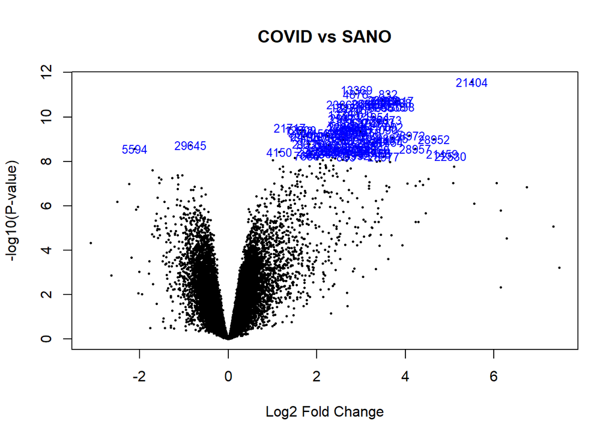

Con el fin de observar si existen perfiles de expresión diferenciados podemo realizar un mapa de colores con los genes más diferencialmente expresados.

```
[1] 226
```

Con la matriz de expresión de los genes que verifican dicha condición se puede construir un heatmap.

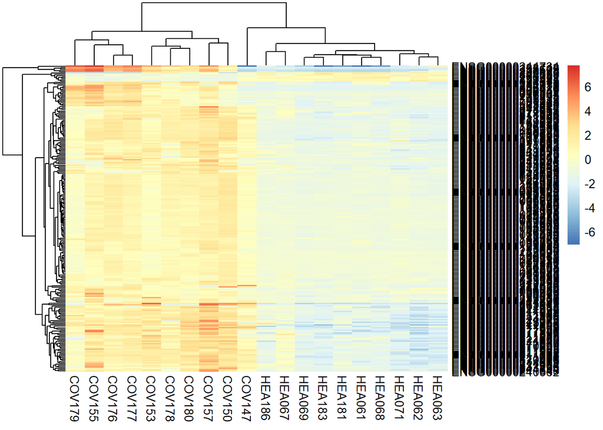

Los dos grupos estan diferenciados, sobre todo en un subconjunto de genes en donde las expresiones toman signos (colores) distintos. En otro de los grupos parece que, en el grupo de individuops sanos los genes diferencialmente expresados se encuentran sobre-expresados en el grupo COVID, y apenas expresados en el grupo sanos.

## 5.2 Análisis de expresión diferencial usando el paquete `edgeR`

El análisis con `edgeR` es similar al anterior (se originan en el mismo equipo de investigación) pero la modelización es distinta.

El análisis utiliza un GLM pero, en una forma que recuerda a lo que se hace con `limma`, realiza un paso adicional,en el que se calcula una estimación mejorada de la dispersión (variabilidad) de las muestras que integra las estimaciones individuales y la global mediante estimación Bayes empírica.

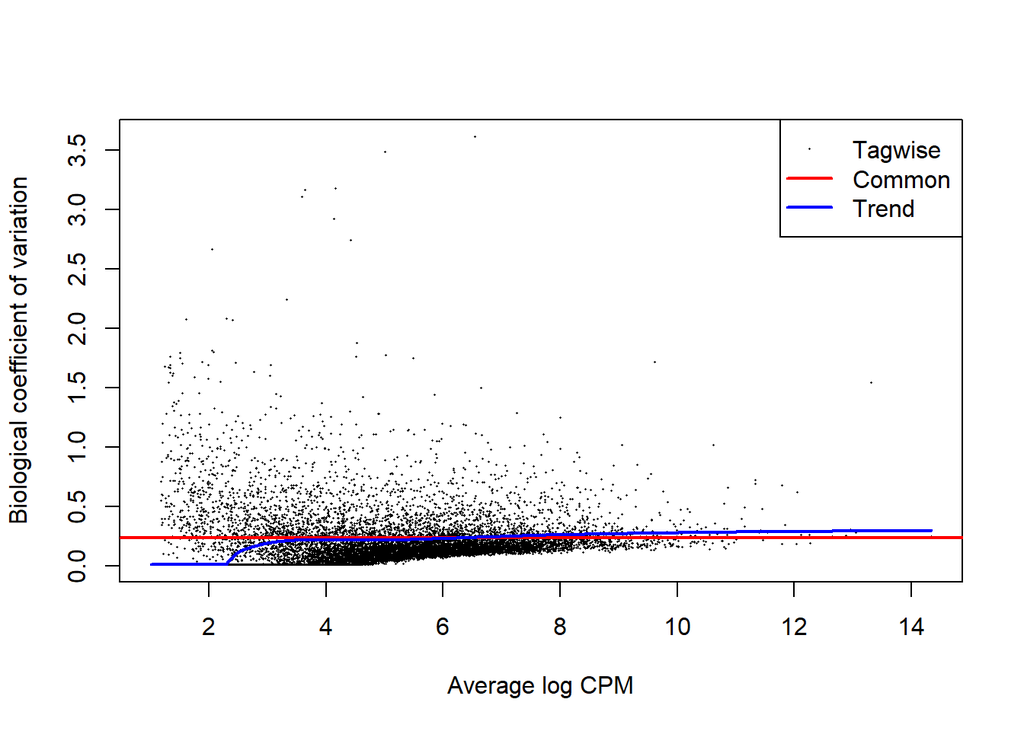

Una vez ajustado el modelo se procede a construir el contraste y realizar el test.

De hecho podemos usar la matriz de contrastes que construímos para limma voom, en la misma forma que hemos reutilizado la de diseño.

```
An object of class "DGELRT"
$coefficients
                    COVID      SANO
ENSG00000227232 -13.94029 -15.20696
ENSG00000278267 -15.19802 -14.73910
ENSG00000233750 -15.61237 -15.64935
ENSG00000268903 -13.95928 -14.03808
ENSG00000269981 -14.36185 -14.23631
ENSG00000241860 -15.04061 -14.94794

$fitted.values
                    COV178    COV176     COV155     COV157     COV147
ENSG00000227232 0.81238202 0.7272834 0.59815121 0.77268579 0.80314682
ENSG00000278267 0.13527184 0.1211018 0.09959971 0.12866192 0.13373406
ENSG00000233750 0.04403126 0.0394189 0.03241991 0.04187972 0.04353071
                    COV150     COV177     COV153     COV179     COV180
ENSG00000227232 0.70102315 0.73453772 0.75234596 0.74741796 0.78160218
ENSG00000278267 0.11672919 0.12230978 0.12527508 0.12445451 0.13014661
ENSG00000233750 0.03799559 0.03981208 0.04077729 0.04051019 0.04236299
                    HEA062     HEA061     HEA186     HEA071     HEA068
ENSG00000227232 0.12583127 0.12149705 0.12301630 0.11805186 0.13322800
ENSG00000278267 0.27642693 0.26690547 0.27024298 0.25933706 0.29267610
ENSG00000233750 0.03558526 0.03435953 0.03478918 0.03338523 0.03767706
                    HEA067     HEA181     HEA069     HEA063     HEA183
ENSG00000227232 0.13506788 0.11793959 0.13885439 0.13003389 0.12583118
ENSG00000278267 0.29671796 0.25909044 0.30503620 0.28565926 0.27642672
ENSG00000233750 0.03819738 0.03335348 0.03926821 0.03677376 0.03558523
 [ reached getOption("max.print") -- omitted 3 rows ]

$deviance
ENSG00000227232 ENSG00000278267 ENSG00000233750 ENSG00000268903 ENSG00000269981
       8.038336        2.049878        1.139185        2.402179        4.003820
ENSG00000241860
       1.727961

$method
[1] "oneway"

$unshrunk.coefficients
                    COVID      SANO
```

[output cut: 86 more lines]

```
ENSG00000268903  0.11369581 1.435709  0.19546741 0.86142977
ENSG00000269981 -0.18111395 1.316721  0.29567270 0.80497372
ENSG00000241860 -0.13368992 1.124027  0.20783383 0.88145168

$comparison
[1] "1*COVID -1*SANO"

$df.test
[1] 1 1 1 1 1 1

$df.total
ENSG00000227232 ENSG00000278267 ENSG00000233750 ENSG00000268903 ENSG00000269981
       24.47432        27.19756        27.19756        27.19756        27.19756
ENSG00000241860
       27.19756
```

Los resultados se almacenan en un objeto similar a la ’ topTable’ de `limma`.

```
Coefficient:  1*COVID -1*SANO
                          genes    logFC   logCPM        F       PValue
ENSG00000123485 ENSG00000123485 3.305469 3.011572 131.7494 6.193350e-12
ENSG00000178999 ENSG00000178999 3.249431 3.400902 133.9361 7.027956e-12
ENSG00000167513 ENSG00000167513 2.856976 3.154527 119.2878 1.895162e-11
ENSG00000184661 ENSG00000184661 3.358564 2.756069 118.9837 1.949912e-11
ENSG00000017483 ENSG00000017483 1.692430 5.350873 115.5182 2.709091e-11
ENSG00000117399 ENSG00000117399 3.892694 4.194982 141.7325 3.929462e-11
                         FDR
ENSG00000123485 1.050855e-07
ENSG00000178999 1.050855e-07
ENSG00000167513 1.457803e-07
ENSG00000184661 1.457803e-07
ENSG00000017483 1.620307e-07
ENSG00000117399 1.958509e-07
```

El resultado se puede guardar en un archivo de texto para su posterior explotación.

Podemos seleccionar los genes más diferencialmente expresados de la misma forma que hicimos con limma-voom

```
[1] 276
```

Obsérvese que la lista de genes seleccionados es muy similar en ambos casos.

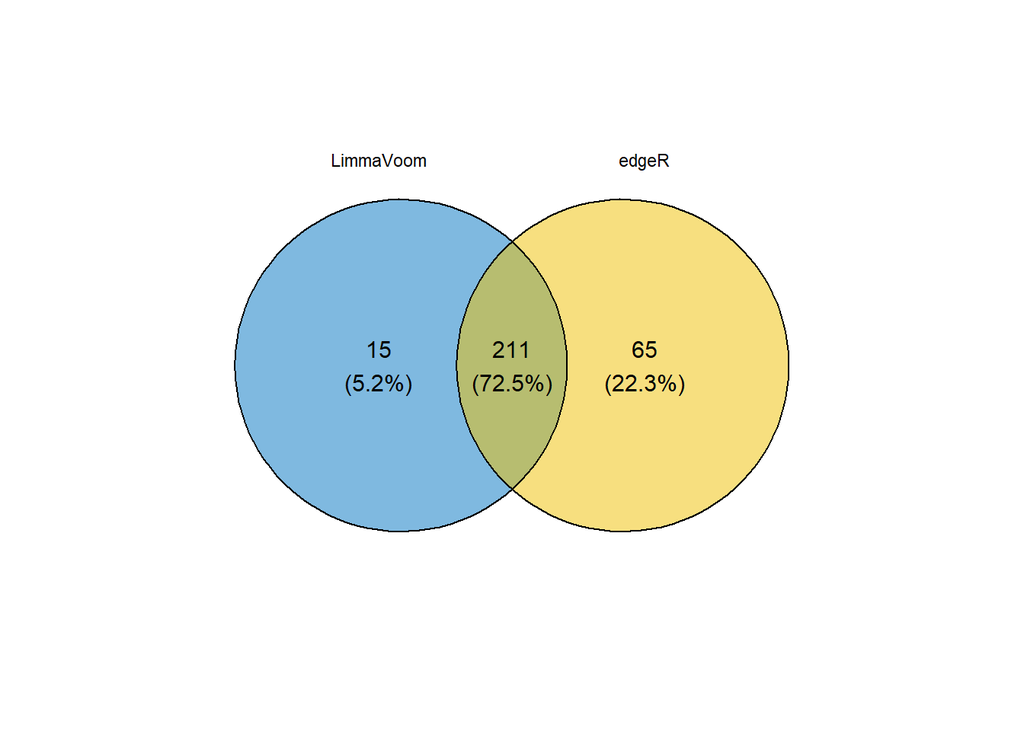

El ejercicio pedía únicamente comparar los resultados de la selección con limmaVoom con otro método alternativo por lo que, por simplicidad omitiremos el análisis con DESEQ2 que puede verse aplicado en el ejemplo disponible en el ejemplo siguiente: https://github.com/ASPteaching/Omics_data_analysis-Case_study_2-RNA-seq.

# 6 Anotación de resultados y análisis de significación biológica

Para el análisis de significación se utilizan dos listas de transcritos:

- La lista de transcritos diferencialmenete expresados
- La lista de tosos los tránscritos o “Universo”

Una alternativa obvia para definir la lista de transcritos diferencialmente expresados sería tomar los genes que han sido seleccionados por ambos métodos, es decir por `edgeR` y `limma-Voom`, que es una selección restrictiva pero fiable.

Como este tipo de análisis es muy exploratorio se utilizará una opción menos restrictiva, la unión de abas listas, es decir, los genes que han sido seleccionados por uno u otro de los métodos.

```
[1] 291
```

```
[1] 29905
```

## 6.1 Anotación de los identificadores

Un detalle importante en los estudios de RNA-seq es que las unidades de expresión suelen ser *tránscritos* no genes. En la práctica, esto determina que la mayoría de programas de análisis de enriquecimiento pueden perder detalle, porque para su uso se requiere tener los identificadores en formato “gen”, habitualmente ENTREZ o SYMBOL.

Esto es posible, y de hecho sencillo de llevar a cabo, usando el paquete `annotate`.

```
 [1] "ACCNUM"       "ALIAS"        "ENSEMBL"      "ENSEMBLPROT"  "ENSEMBLTRANS"
 [6] "ENTREZID"     "ENZYME"       "EVIDENCE"     "EVIDENCEALL"  "GENENAME"
[11] "GENETYPE"     "GO"           "GOALL"        "IPI"          "MAP"
[16] "OMIM"         "ONTOLOGY"     "ONTOLOGYALL"  "PATH"         "PFAM"
[21] "PMID"         "PROSITE"      "REFSEQ"       "SYMBOL"       "UCSCKG"
[26] "UNIPROT"
```

```
          ENSEMBL   SYMBOL ENTREZID
1 ENSG00000211896    IGHG1     3500
2 ENSG00000184661    CDCA2   157313
3 ENSG00000117399    CDC20      991
4 ENSG00000123485    HJURP    55355
5 ENSG00000166851     PLK1     5347
6 ENSG00000211962 IGHV1-46    28465
                                            GENENAME
1 immunoglobulin heavy constant gamma 1 (G1m marker)
2                   cell division cycle associated 2
3                             cell division cycle 20
4              Holliday junction recognition protein
5                                 polo like kinase 1
6                 immunoglobulin heavy variable 1-46
```

```
[1] 291   4
```

Como puede verse, el número de anotaciones es el mismo que el de identificadores ENSEMBL, lo que podría llevar a pensar que, es posible que, antes de subir los datos a GEO se hayan agrupado los contajes por genes.

Para la anotación del universo se procederá igual.

```
          ENSEMBL   SYMBOL ENTREZID
1 ENSG00000211896    IGHG1     3500
2 ENSG00000184661    CDCA2   157313
3 ENSG00000117399    CDC20      991
4 ENSG00000123485    HJURP    55355
5 ENSG00000166851     PLK1     5347
6 ENSG00000211962 IGHV1-46    28465
                                            GENENAME
1 immunoglobulin heavy constant gamma 1 (G1m marker)
2                   cell division cycle associated 2
3                             cell division cycle 20
4              Holliday junction recognition protein
5                                 polo like kinase 1
6                 immunoglobulin heavy variable 1-46
```

```
[1] 30069     4
```

## 6.2 Análisis de enriquecimiento

El paquete `clusterProfiler` admite identificadores de tipo ENSEMBL y permite gran variedad de análisis complementarios al enriquecimiento por lo que, es una de las mejores opcionespara el análisis de significación biológica.

En primer lugar se lleva a cabo un *Análisis de enriquecimiento* con categorias de la ontología “Biological Process” que permite seleccionar aquellas categorías más enriquecidas en la lista de genes diferencialmente expresados.

El objeto resultante del análisis contiene información sobre las categorías enriquecidas, el grado de enriquecimiento, o los genes anotados en las mismas. Este objeto puede salvarse a disco para su posterior consulta.

```
                   ID GeneRatio   BgRatio       pvalue     p.adjust
GO:0006958 GO:0006958    68/265 115/15262 4.550993e-92 1.074944e-88
GO:0002455 GO:0002455    69/265 130/15262 8.071654e-89 9.532624e-86
GO:0006956 GO:0006956    68/265 141/15262 1.221492e-83 9.617214e-81
GO:0016064 GO:0016064    69/265 195/15262 2.998165e-73 1.770416e-70
GO:0019724 GO:0019724    69/265 198/15262 1.051555e-72 4.967544e-70
                 qvalue Count
GO:0006958 9.715171e-89    68
GO:0002455 8.615429e-86    69
GO:0006956 8.691880e-81    68
GO:0016064 1.600073e-70    69
GO:0019724 4.489585e-70    69
```

```
                                                              Description
GO:0006958                       complement activation, classical pathway
GO:0002455 humoral immune response mediated by circulating immunoglobulin
GO:0006956                                          complement activation
GO:0016064                        immunoglobulin mediated immune response
GO:0019724                                       B cell mediated immunity
           GeneRatio
GO:0006958    68/265
GO:0002455    69/265
GO:0006956    68/265
GO:0016064    69/265
GO:0019724    69/265
```

```
                                                              Description
GO:0006958                       complement activation, classical pathway
GO:0002455 humoral immune response mediated by circulating immunoglobulin
GO:0006956                                          complement activation
GO:0016064                        immunoglobulin mediated immune response
GO:0019724                                       B cell mediated immunity
                                                                                                                                                                                                                                                                                                            …
GO:0006958      IGHG1/IGHV4-59/IGKV4-1/IGKC/IGHV3-21/IGLC2/IGLV3-25/IGHV4-34/IGHV1-18/IGLV2-14/IGKV1-16/IGLV3-19/IGKV5-2/IGHV3-11/IGHV3-33/IGHV3-23/IGHV1-24/IGLC3/IGLV1-40/IGKV1-5/IGKV3-15/IGLV2-11/IGHV5-51/IGHV4-28/IGHV3-49/IGHG3/IGLV6-57/IGLV1-44/IGLV2-23/IGLV1-47/IGHG2/IGHV3-66/C1QC/IGHV3-30/IGHV…
GO:0002455 IGHG1/IGHV4-59/IGKV4-1/IGKC/IGHV3-21/IGLC2/IGLV3-25/IGHV4-34/IGHV1-18/IGLV2-14/IGKV1-16/IGLV3-19/IGKV5-2/IGHV3-11/IGHV3-33/IGHV3-23/IGHV1-24/IGLC3/IGLV1-40/IGKV1-5/IGKV3-15/IGLV2-11/EXO1/IGHV5-51/IGHV4-28/IGHV3-49/IGHG3/IGLV6-57/IGLV1-44/IGLV2-23/IGLV1-47/IGHG2/IGHV3-66/C1QC/IGHV3-30/IGHV…
GO:0006956      IGHG1/IGHV4-59/IGKV4-1/IGKC/IGHV3-21/IGLC2/IGLV3-25/IGHV4-34/IGHV1-18/IGLV2-14/IGKV1-16/IGLV3-19/IGKV5-2/IGHV3-11/IGHV3-33/IGHV3-23/IGHV1-24/IGLC3/IGLV1-40/IGKV1-5/IGKV3-15/IGLV2-11/IGHV5-51/IGHV4-28/IGHV3-49/IGHG3/IGLV6-57/IGLV1-44/IGLV2-23/IGLV1-47/IGHG2/IGHV3-66/C1QC/IGHV3-30/IGHV…
GO:0016064 IGHG1/IGHV4-59/IGKV4-1/IGKC/IGHV3-21/IGLC2/IGLV3-25/IGHV4-34/IGHV1-18/IGLV2-14/IGKV1-16/IGLV3-19/IGKV5-2/IGHV3-11/IGHV3-33/IGHV3-23/IGHV1-24/IGLC3/IGLV1-40/IGKV1-5/IGKV3-15/IGLV2-11/EXO1/IGHV5-51/IGHV4-28/IGHV3-49/IGHG3/IGLV6-57/IGLV1-44/IGLV2-23/IGLV1-47/IGHG2/IGHV3-66/C1QC/IGHV3-30/IGHV…
GO:0019724 IGHG1/IGHV4-59/IGKV4-1/IGKC/IGHV3-21/IGLC2/IGLV3-25/IGHV4-34/IGHV1-18/IGLV2-14/IGKV1-16/IGLV3-19/IGKV5-2/IGHV3-11/IGHV3-33/IGHV3-23/IGHV1-24/IGLC3/IGLV1-40/IGKV1-5/IGKV3-15/IGLV2-11/EXO1/IGHV5-51/IGHV4-28/IGHV3-49/IGHG3/IGLV6-57/IGLV1-44/IGLV2-23/IGLV1-47/IGHG2/IGHV3-66/C1QC/IGHV3-30/IGHV…
```

Con los resultados del análisis de enriquecimiento se pueden llevar a cabo distintas visualizaciones cuya interpretación exacta puede verse en el manual de clusterProfiler.

Un dotplot muestra algunas categorias usando un código de tamaño para el número de genes en la categoría y de color para la significación.

[figure not shown]

Un `cnetplot`muestra la relación entre genes y categorías enriquecidas.

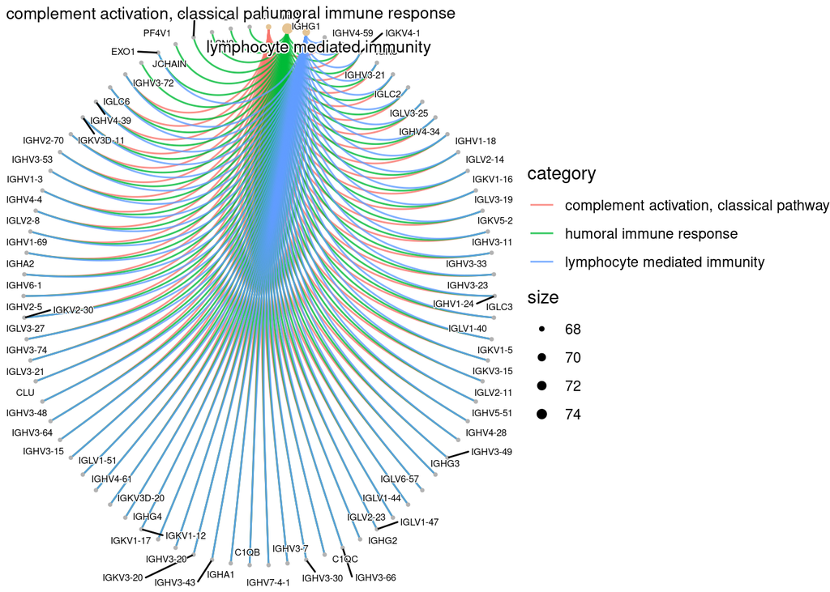

Un `goplot` muestra, en forma de subgrafo de la Gene Ontology, las categorías que se relacionan, como ascendientes, con las categorías enriquecidas. Sirve para ver éstas, en contexto.

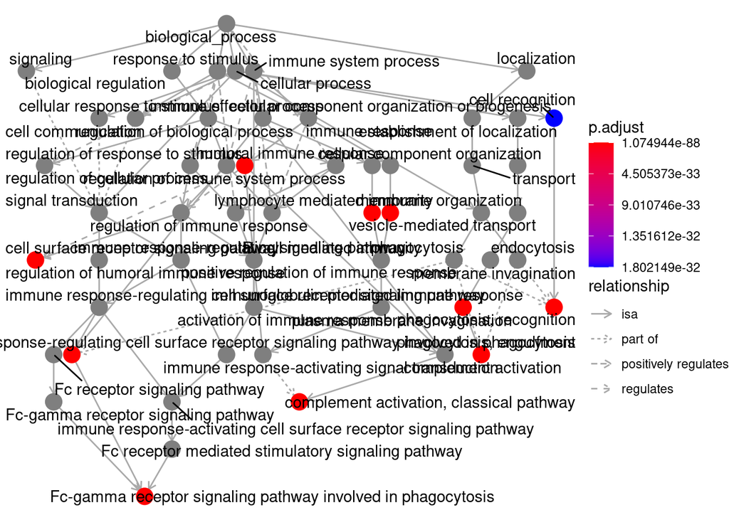

Un heatplot`permite relacionar, de forma similar al cnetplot, las categorías y los genes anotados en ellas. Conceptualmente es interesante, pero la visibilidad es difícil.

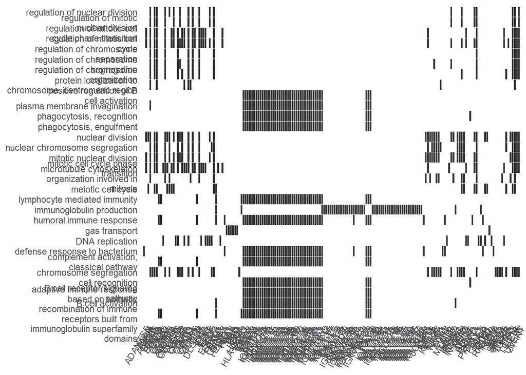

Finalmente, dada la abundancia de componentes que aparecen en los análisis, podemos mirar de agruparlos por su similaridad (cercanía dentro del grafo) y así obtener una visualización más compacta.

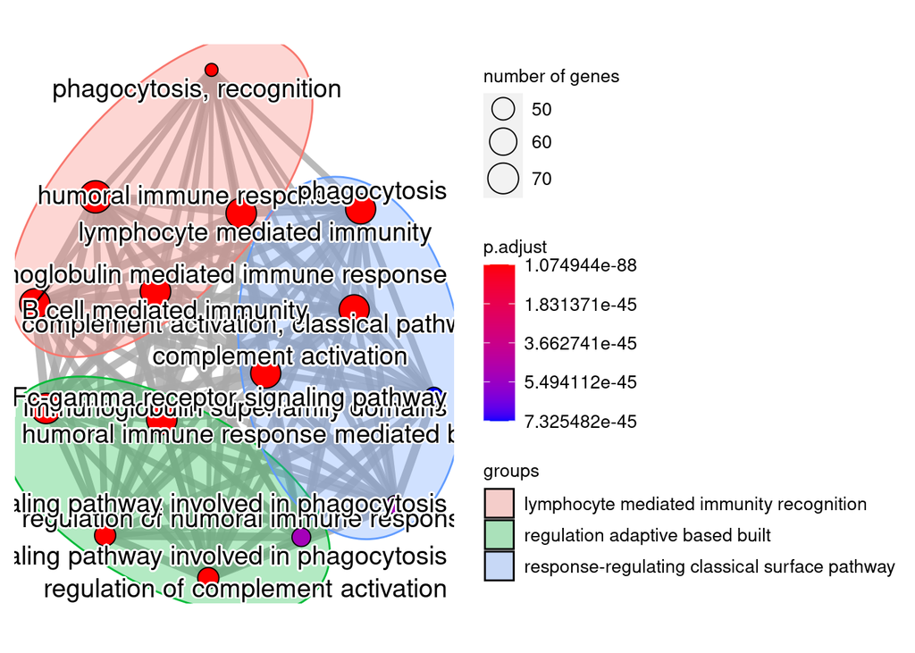

Todos los gráficos se pueden, adicionalmente, enviar a una rchivo pdf para su posterior visualización.

# 7 Discusión

# 8 Apendice: Codigo del Análisis

Para extraer el código de este documento podemos usar la instrucción `knitr::purl("ADO-PEC2-RNA-seq-Solucion-v0.Rmd")` con el nombre del archivo.

Si insertamos el archivo resultante en un “chunk de código” marcado con `eval=FALSE` podremos ver todo el código con el formato adecuado.

```r
## ----class.source = 'fold-hide', setup, include=FALSE---------------------
## library(knitr) library(rmdformats) ## Global options options(max.print='75')
## opts_chunk$set(echo=FALSE, \t cache=TRUE, prompt=FALSE, tidy=TRUE,
## comment=NA, message=FALSE, warning=FALSE) opts_knit$set(width=75)


## ----instalaPaquetes, librerias, echo=TRUE, eval=FALSE--------------------
if (!require(BiocManager)) {
    install.packages("BiocManager", dep = TRUE)
}

installifnot <- function(pckgName, BioC = TRUE) {
    if (BioC) {
        if (!require(pckgName, character.only = TRUE)) {
            BiocManager::install(pckgName)
        }
    } else {
        if (!require(pckgName, character.only = TRUE)) {
            install.packages(pckgName, dep = TRUE)
        }
    }
}
installifnot("limma")
installifnot("edgeR")
# installifnot('DESeq2')
installifnot("org.Hs.eg.db")
installifnot("clusterProfiler")
installifnot("dplyr", BioC = FALSE)
installifnot("gplots", BioC = FALSE)
installifnot("ggvenn", BioC = FALSE)
installifnot("pheatmap")
installifnot("stringi", BioC = FALSE)
installifnot("prettydoc", BioC = FALSE)
installifnot("ggnewscale", BioC = FALSE)


## ----directorios----------------------------------------------------------
if (!dir.exists("datos")) dir.create("datos")
if (!dir.exists("results")) dir.create("results")


## -------------------------------------------------------------------------
counts <- read.csv("datos/RawCounts.csv", row.names = 1)
countsMatrix <- as.matrix(counts)
rm(counts)


## ----creaTargets----------------------------------------------------------
muestras <- colnames(countsMatrix)
grupos <- c(rep("COVID", 17), rep("SANO", 17))
colores = c(rep("red", 17), rep("blue", 17))
targets <- data.frame(sample = muestras, group = grupos, cols = colores)
rownames(targets) <- targets[, 1]


## ----sincronizacion-------------------------------------------------------
if (sum(colnames(countsMatrix) != rownames(targets)) > 0) cat("Verifique que las filas del objeto targets coinciden con las columnas de la matriz de datos")


## ----getRowsFromGroup-----------------------------------------------------
getRowsFromGroup <- function(unGrupo, numRows) {
    G <- which(targets$group == unGrupo)
    s <- sample(G, numRows)
}


## ----randomSampling-------------------------------------------------------
set.seed(12345678)
S1 <- getRowsFromGroup("COVID", 10)
S2 <- getRowsFromGroup("SANO", 10)
selectedSamples <- c(S1, S2)
# show(selectedSamples)


## ----subconjuntObjetos----------------------------------------------------
selectedCounts <- countsMatrix[, selectedSamples]
selectedTargets <- targets[selectedSamples, ]
dim(selectedCounts)
dim(selectedTargets)
sum(colnames(selectedCounts) != rownames(selectedTargets))


## ----getCPM---------------------------------------------------------------
library(edgeR)
selectedCounts[1:5, 1:6]
counts.CPM <- cpm(selectedCounts)
counts.CPM[1:5, 1:6]


## ----subsetThreshold------------------------------------------------------
thresh <- counts.CPM > 0
keep <- (rowSums(thresh[, 1:10]) >= 3) & (rowSums(thresh[, 11:20]) >= 3)
counts.keep <- counts.CPM[keep, ]
dim(counts.CPM)
dim(counts.keep)


## ----comparaMatrices------------------------------------------------------
head(counts.CPM)
head(counts.keep)


## ----makeDGEObj0----------------------------------------------------------
dgeObj <- DGEList(counts = counts.keep, lib.size = colSums(counts.keep), norm.factors = rep(1,
    ncol(counts.keep)), samples = selectedTargets, group = selectedTargets$group,
    genes = rownames(counts.keep), remove.zeros = FALSE)
dgeObj


## ----makeDGEObj-----------------------------------------------------------
dim(dgeObj)
dgeObjShort <- dgeObj[, c(1:5, 11:15)]
# Library size information is stored in the samples slot
dgeObjShort$samples
colnames(dgeObjShort$counts)


## ----calcNormFactors------------------------------------------------------
library(edgeR)
dgeObj_norm <- calcNormFactors(dgeObj)


## -------------------------------------------------------------------------
dgeObj$counts[1:3, 1:5]
dgeObj_norm$counts[1:3, 1:5]
dgeObj$samples$norm.factors
dgeObj_norm$samples$norm.factors


## ----log2count_norm-------------------------------------------------------
log2count_norm <- cpm(dgeObj_norm, log = TRUE)


## ----distriCounts1--------------------------------------------------------
par(mfrow = c(2, 1))
rawCounts <- dgeObj_norm$counts
boxplot(rawCounts, ylab = "CPM", las = 2, xlab = "", col = dgeObj$samples$cols, cex.axis = 0.7,
    main = "Distribución de contajes")
boxplot(log2count_norm, ylab = "Log2-CPM", las = 2, xlab = "", col = dgeObj$samples$cols,
    cex.axis = 0.7, main = "Distribución de log(contajes)")
abline(h = median(log2count_norm), col = "blue")
par(mfrow = c(1, 1))


## -------------------------------------------------------------------------
sampleDists <- dist(t(log2count_norm))
round(sampleDists, 1)


## -------------------------------------------------------------------------
library(factoextra)
fviz_dist(sampleDists)


## -------------------------------------------------------------------------
hc <- hclust(sampleDists)
plot(hc, labels = colnames(log2count_norm), main = "Agrpamiento jerárquico de las muestras",
    cex = 0.8)


## -------------------------------------------------------------------------
normFactors <- dgeObj_norm$samples$norm.factors
names(normFactors) <- sampleNames <- rownames(dgeObj_norm$samples)
plot(normFactors, main = "Factores de normalización")
text(normFactors, sampleNames, pos = 2, cex = 0.7)


## -------------------------------------------------------------------------
## sampleinfo$Status <- factor (sampleinfo$group)
col.status <- dgeObj_norm$samples$cols
plotMDS(log2count_norm, col = col.status, main = "Status", cex = 0.7)


## ----matrizDisenyo--------------------------------------------------------
group = as.factor(dgeObj_norm$samples$group)
design = model.matrix(~0 + group)
colnames(design) = gsub("group", "", colnames(design))
row.names(design) = sampleNames
design


## ----matrizContrastes-----------------------------------------------------
cont.matrix = makeContrasts(CONTROLvsCOVID = COVID - SANO, levels = colnames(design))
cont.matrix


## ----voom-----------------------------------------------------------------
voomObj <- voom(dgeObj_norm, design)
voomObj


## ----ajusteLM-------------------------------------------------------------
fit <- lmFit(voomObj)
fit.cont <- contrasts.fit(fit, cont.matrix)
fit.cont <- eBayes(fit.cont)


## ----topTable-------------------------------------------------------------
toptab <- topTable(fit.cont, coef = 1, sort.by = "p", number = nrow(fit.cont))
head(toptab)


## ----volcano--------------------------------------------------------------
volcanoplot(fit.cont, coef = 1, highlight = 100, main = "COVID vs SANO")


## ----deg1VOOM-------------------------------------------------------------
topGenesBas <- rownames(subset(toptab, (abs(logFC) > 2) & (adj.P.Val < 0.01)))
length(topGenesBas)


## ----mapaDeColores--------------------------------------------------------
library(pheatmap)
mat <- log2count_norm[topGenesBas, ]
mat <- mat - rowMeans(mat)
pheatmap(mat)


## -------------------------------------------------------------------------
y = estimateDisp(dgeObj_norm, design, robust = TRUE)
plotBCV(y)


## -------------------------------------------------------------------------
fit <- glmQLFit(y, design, robust = TRUE)


## -------------------------------------------------------------------------
res <- glmQLFTest(fit, contrast = cont.matrix)
head(res)


## -------------------------------------------------------------------------
topTags_edge <- topTags(res, n = dim(log2count_norm)[1])  # todos los genes
head(topTags_edge)


## -------------------------------------------------------------------------
topGenes_edge <- rownames(subset(topTags_edge$table, (abs(logFC) > 2) & (FDR < 0.01)))
length(topGenes_edge)


## ----comparaVoomEdgeR-----------------------------------------------------
library(ggvenn)
x = list(LimmaVoom = topGenesBas, edgeR = topGenes_edge)
ggvenn(x, fill_color = c("#0073C2FF", "#EFC000FF"), stroke_size = 0.5, set_name_size = 3)


## -------------------------------------------------------------------------
topGenes <- union(topGenesBas, topGenes_edge)
length(topGenes)
universe <- rownames(toptab)
length(universe)


## ----anotaTop-------------------------------------------------------------
library(org.Hs.eg.db)
AnnotationDbi::keytypes(org.Hs.eg.db)
topAnots = AnnotationDbi::select(org.Hs.eg.db, topGenes, c("SYMBOL", "ENTREZID",
    "GENENAME"), keytype = "ENSEMBL")
head(topAnots)
dim(topAnots)


## -------------------------------------------------------------------------
univAnots = AnnotationDbi::select(org.Hs.eg.db, universe, c("SYMBOL", "ENTREZID",
    "GENENAME"), keytype = "ENSEMBL")
head(univAnots)
dim(univAnots)


## ----enrichment-----------------------------------------------------------
library(clusterProfiler)
library(org.Hs.eg.db)
ego = enrichGO(gene = topGenes, universe = universe, keyType = "ENSEMBL", OrgDb = org.Hs.eg.db,
    ont = "BP", pAdjustMethod = "BH", pvalueCutoff = 0.05, qvalueCutoff = 0.05, readable = TRUE)


## ----saveEnrichedTerms----------------------------------------------------
head(ego[, -c(2, 8)], n = 5)
head(ego[, 2:3], n = 5)
head(ego[, c(2, 8)], n = 5)
write.table(ego, file = "results/EnrichmentResults.csv", dec = ".", sep = ";")


## ----viewEnrichment1------------------------------------------------------
dotplot(ego, showCategory = 7)


## ----viewEnrichment2------------------------------------------------------
library(ggplot2)
ego2 = simplify(ego)
cnetplot(ego2, showCategory = 3, cex_category = 0.3, cex_label_category = 0.7, cex_gene = 0.2,
    cex_label_gene = 0.4, circular = TRUE, colorEdge = TRUE)


## ----viewEnrichment3------------------------------------------------------
library(enrichplot)
goplot(ego2, showCategory = 10, cex = 0.1)


## ----viewEnrichment5------------------------------------------------------
heatplot(ego2)


## ----viewEnrichment6------------------------------------------------------
term_similarity_matrix = pairwise_termsim(ego)
emapplot(term_similarity_matrix, showCategory = 15, group_category = TRUE, group_legend = TRUE)


## -------------------------------------------------------------------------
pdf(file = "results/enrichmentPlots.pdf")
dotplot(ego, showCategory = 7)
cnetplot(ego2, showCategory = 3, cex_category = 0.3, cex_label_category = 0.7, cex_gene = 0.2,
    cex_label_gene = 0.4, circular = TRUE, colorEdge = TRUE)
goplot(ego2, showCategory = 10, cex = 0.1)
heatplot(ego2)
emapplot(term_similarity_matrix, showCategory = 15, group_category = TRUE, group_legend = TRUE)
dev.off()


## ----insertaCodigo, echo=TRUE, eval=FALSE, highlight=TRUE----------------
```